# 1 Introduction

## 4.8 Correlation Heatmap - Demand

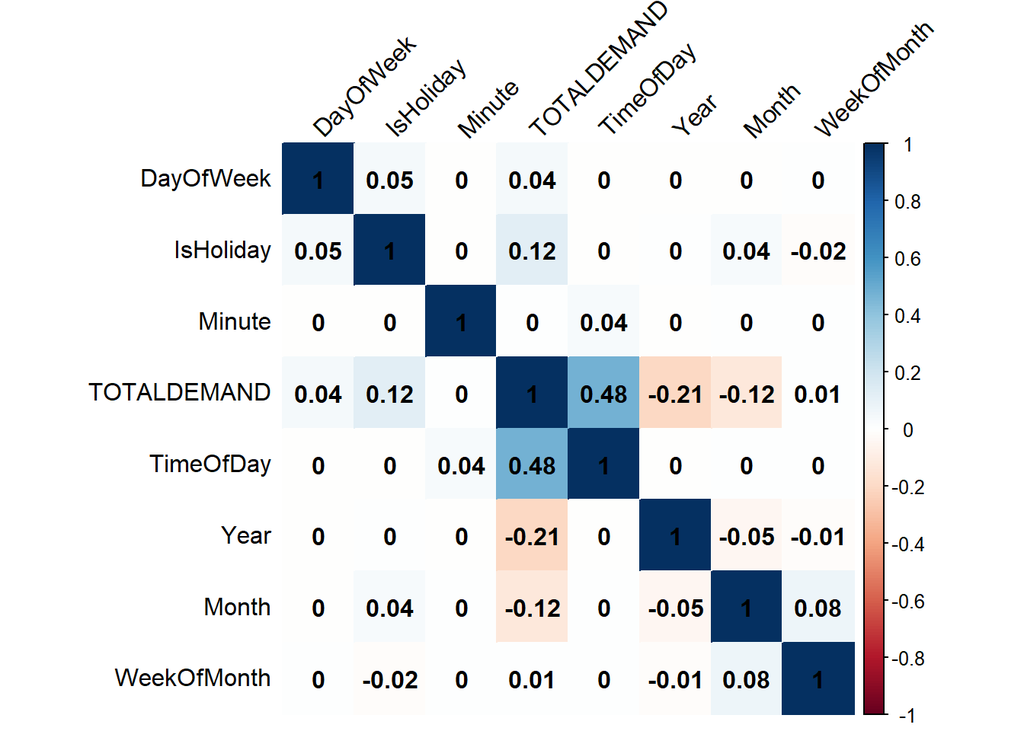

Figure 4.6: Correlation Map of Demand and Time.

```r
cor_df <- df_demand_nsw %>%
  select(-DATETIME, -REGIONID, -Date) %>%
  mutate(IsHoliday = case_when(IsHoliday == 'Holiday' ~ 0, TRUE ~ 1)) %>%
  mutate(across(everything(), as.numeric)) %>%
  select(-Day,-Hour)

cor_matrix <- cor(cor_df)

corrplot(cor_matrix, method = "color", type = "full", order = "hclust",
         tl.col = "black", tl.srt = 45,
         addCoef.col = "black")
```

## 4.9 Correlation Heatmap - Daily data

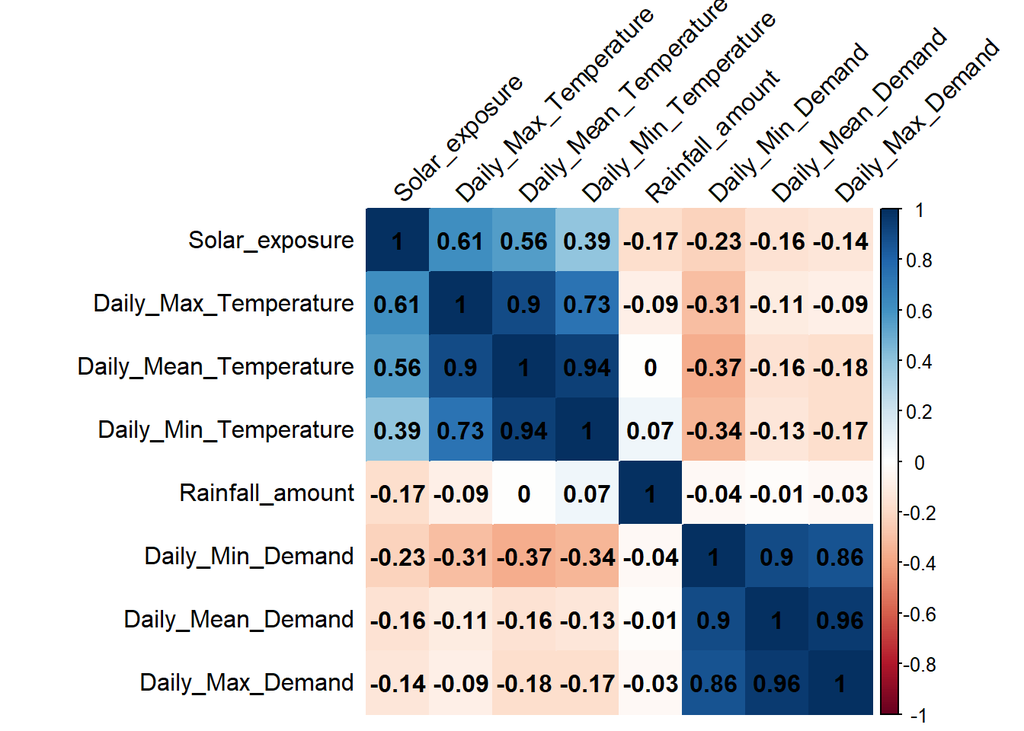

Figure 4.7: Correlation Map of Daily Data.

```r
cor_df2 <- df_nsw_daily %>%
  select(-DATE, -WeekOfMonth, -DayOfWeek)

cor_matrix2 <- cor(cor_df2)


corrplot(cor_matrix2, method = "color", type = "full", order = "hclust",
         tl.col = "black", tl.srt = 45,
         addCoef.col = "black")
```

## 4.10 STL decomposition

```r
electricity_ts <- df_demand_nsw %>%
  select(DATETIME, TOTALDEMAND) %>%
  as_tsibble(index = DATETIME)
```

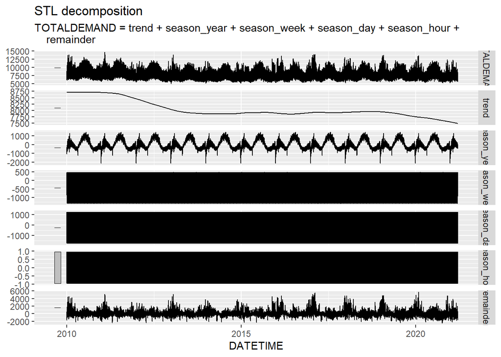

Figure 4.8: STL Decomposition.

```r
decomposed <- electricity_ts %>%
  model(STL = STL(TOTALDEMAND ~ season(window = "periodic"),
                  robust = TRUE)) %>%
  components()

decomposed %>% autoplot()
```

The STL decomposition shows multiple seasonality, hourly, daily, weekly and yearly.

```r
# Extracting seasonal components
seasonal_components <- decomposed %>%
  select(trend, season_hour , season_day, season_week, season_year )
```

```r
lm_model <- decomposed %>%
  model(lm = TSLM(TOTALDEMAND  ~ trend + season_hour + season_day + season_week + season_year))

report(lm_model)
```

```
## Series: TOTALDEMAND
## Model: TSLM
##
## Residuals:
##      Min       1Q   Median       3Q      Max
## -2641.37  -379.62   -56.34   275.68  5656.07
##
## Coefficients:
##               Estimate Std. Error t value Pr(>|t|)
## (Intercept) -2.275e+02  3.665e+01  -6.209 5.35e-10 ***
## trend        1.038e+00  4.557e-03 227.792  < 2e-16 ***
## season_hour  1.815e+00  1.583e+00   1.147    0.252
## season_day   1.047e+00  1.754e-03 597.203  < 2e-16 ***
## season_week  9.726e-01  3.907e-03 248.905  < 2e-16 ***
## season_year  9.581e-01  3.034e-03 315.781  < 2e-16 ***
## ---
## Signif. codes:  0 '***' 0.001 '**' 0.01 '*' 0.05 '.' 0.1 ' ' 1
##
## Residual standard error: 663.9 on 196507 degrees of freedom
## Multiple R-squared: 0.739,   Adjusted R-squared: 0.739
## F-statistic: 1.113e+05 on 5 and 196507 DF, p-value: < 2.22e-16
```

Hourly seasonality seem to be weak.

## 4.11 Autocorrelation

```r
dfts_demand_nsw <- as_tsibble(df_demand_nsw %>% select(DATETIME, TOTALDEMAND), index=DATETIME)
```

### 4.11.1 Non-Seasonal Differencing

```r
dfts_demand_nsw %>% features(TOTALDEMAND, unitroot_kpss)
```

```
## # A tibble: 1 × 2
##   kpss_stat kpss_pvalue
##       <dbl>       <dbl>
## 1      66.3        0.01
```

```r
dfts_demand_nsw %>%
  mutate(diff_TOTALDEMAND = difference(TOTALDEMAND)) %>%
  features(diff_TOTALDEMAND, unitroot_kpss)
```

```
## # A tibble: 1 × 2
##   kpss_stat kpss_pvalue
##       <dbl>       <dbl>
## 1 0.0000830         0.1
```

### 4.11.2 Seasonal Differencing

```r
# 0.01 Non-stationary
dfts_demand_nsw %>%
  features(TOTALDEMAND, unitroot_kpss)
```

```
## # A tibble: 1 × 2
##   kpss_stat kpss_pvalue
##       <dbl>       <dbl>
## 1      66.3        0.01
```

```r
# 0.1 Stationary after first order differencing
dfts_demand_nsw %>%
  mutate(diff_TOTALDEMAND = difference(TOTALDEMAND, 48)) %>%
  features(diff_TOTALDEMAND, unitroot_kpss)
```

```
## # A tibble: 1 × 2
##   kpss_stat kpss_pvalue
##       <dbl>       <dbl>
## 1   0.00116         0.1
```

The KPSS test suggests that after first-order differencing the model is stationary. (Both non-seasonal and seasonal)

### 4.11.3 ACF and PACF after first-order differencing

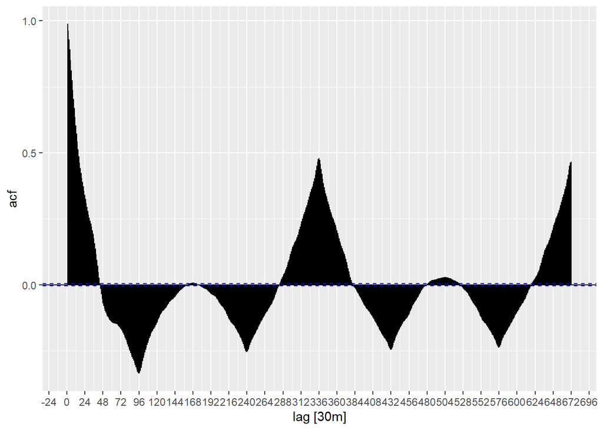

Figure 4.9: Seasonally Differenced ACF plot of Demand Data.

```r
dfts_demand_nsw %>%
  mutate(diff_TOTALDEMAND = difference(TOTALDEMAND, 48)) %>%
  ACF(diff_TOTALDEMAND, lag_max = 336*2) %>%
  autoplot()
```

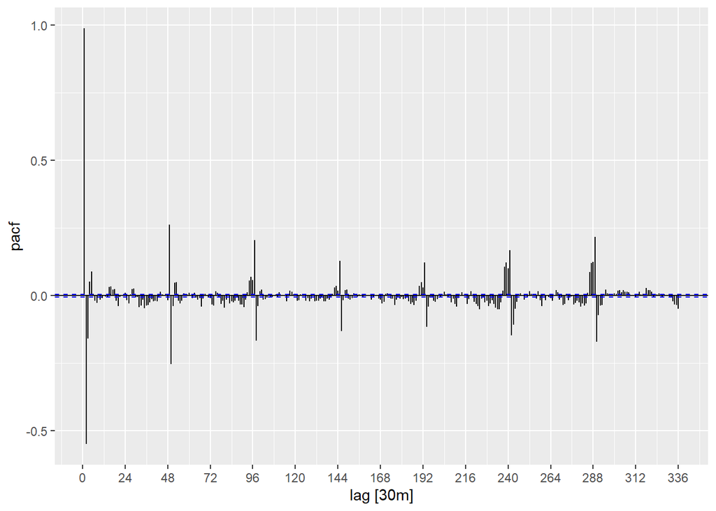

Figure 4.10: Seasonally Differenced PACF plot of Demand Data.

```r
dfts_demand_nsw %>%
  mutate(diff_TOTALDEMAND = difference(TOTALDEMAND, 48)) %>%
  PACF(diff_TOTALDEMAND, lag_max = 336) %>%
  autoplot()
```

# 5 Modelling

## 5.1 Data preperation for modelling

Combining the data into a single dataframe

```r
df_lj <- left_join(df_demand_nsw, df_aligned_temperature_nsw, by='DATETIME')
check_for_na(df_lj)
```

```
## Dataframe: 'df_lj'
##   - Column 'DATETIME': FALSE
##   - Column 'TOTALDEMAND': FALSE
##   - Column 'REGIONID': FALSE
##   - Column 'Year': FALSE
##   - Column 'Month': FALSE
##   - Column 'Day': FALSE
##   - Column 'Hour': FALSE
##   - Column 'Minute': FALSE
##   - Column 'TimeOfDay': FALSE
##   - Column 'WeekOfMonth': FALSE
##   - Column 'DayOfWeek': FALSE
##   - Column 'Date': FALSE
##   - Column 'IsHoliday': FALSE
##   - Column 'TEMPERATURE': TRUE, NA rows: 559
```

```r
# Fill NA values
df_lj$TEMPERATURE <- na.spline(df_lj$TEMPERATURE)
```

Fills NA values with na.spline()

```r
# Uses the latest last change date
df_forecastdemand_nsw <- data_forecastdemand_nsw %>%
  mutate(DATETIME = as_datetime(DATETIME, tz='AUstralia/Brisbane')) %>%
  mutate(DATETIME = DATETIME - hours(10)) %>%  # Shift DATETIME by 10 hours earlier
  group_by(DATETIME) %>%
  filter(LASTCHANGED == max(LASTCHANGED)) %>%
  summarize(FORECASTDEMAND = mean(FORECASTDEMAND), .groups = 'drop') %>%
  ungroup()
```

```r
df_nsw <- left_join(df_lj, df_forecastdemand_nsw, by='DATETIME')
check_for_na(df_nsw)
```

```
## Dataframe: 'df_nsw'
##   - Column 'DATETIME': FALSE
##   - Column 'TOTALDEMAND': FALSE
##   - Column 'REGIONID': FALSE
##   - Column 'Year': FALSE
##   - Column 'Month': FALSE
##   - Column 'Day': FALSE
##   - Column 'Hour': FALSE
##   - Column 'Minute': FALSE
##   - Column 'TimeOfDay': FALSE
##   - Column 'WeekOfMonth': FALSE
##   - Column 'DayOfWeek': FALSE
##   - Column 'Date': FALSE
##   - Column 'IsHoliday': FALSE
##   - Column 'TEMPERATURE': FALSE
##   - Column 'FORECASTDEMAND': FALSE
```

```r
df <- df_nsw %>%
  select(DATETIME, TOTALDEMAND, TEMPERATURE, FORECASTDEMAND) %>%
  mutate(
    TEMPERATURE_SQ = TEMPERATURE^2
  ) %>%
  as_tsibble(index = DATETIME)
```

## 5.2 Model Comparison

```r
start_date <- ymd("2015-06-01")
end_date <- ymd("2018-06-30")

dfts_nsw <- df %>%
  select(DATETIME, TOTALDEMAND, TEMPERATURE, FORECASTDEMAND,TEMPERATURE_SQ) %>%
  as_tsibble(index = DATETIME) %>%
  filter(DATETIME >= start_date & DATETIME <= end_date)
```

```r
n <- nrow(dfts_nsw)

train_set <- dfts_nsw[1:(n-48), ]
test_set <- dfts_nsw[(n-47):n, ]
```

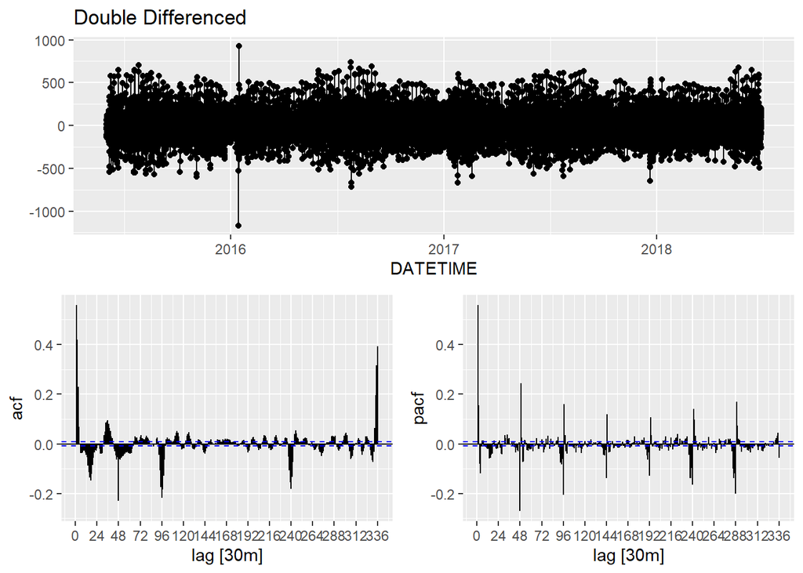

Figure 5.1: Residuals, ACF and PACF of Double Differenced Demand Data.

```r
train_set %>%
  gg_tsdisplay(
    difference(difference(TOTALDEMAND, lag = 48), lag = 1),
    plot_type = 'partial',
    lag_max = 48*7
  ) +
  labs(title = 'Double Differenced', y = '')
```

### 5.2.1 Model Training on Train Set

```r
fit <- train_set %>%
  model(
    arima_fr = ARIMA(TOTALDEMAND ~ pdq(d=1) + PDQ(0,0,0) +
                        fourier(period = 48, K = 3) +     # Daily
                        fourier(period = 48*7, K = 3)),   # Weekly
    sarima_212210 = ARIMA(TOTALDEMAND ~ pdq(2,1,2) + PDQ(2,1,0, period=48)),

    sarima_212210_fr = ARIMA(TOTALDEMAND ~ pdq(2,1,2) + PDQ(2,1,0, period=48) +
                        fourier(period = 48*7, K = 3)), # Weekly

    sarima_auto_temp = ARIMA(TOTALDEMAND ~ pdq(d=1) + PDQ(D=1, period=48) + TEMPERATURE + TEMPERATURE_SQ),

    sarima_212210_temp_fr = ARIMA(TOTALDEMAND ~ pdq(2,1,2) + PDQ(2,1,0, period=48) +
                                TEMPERATURE + TEMPERATURE_SQ +
                                fourier(period = 48*7, K = 3))    # Weekly
  )
```

```r
## Show all models fitted

fit %>% pivot_longer(everything(), names_to = "Model name", values_to = "Orders")
```

```
## # A mable: 5 x 2
## # Key:     Model name [5]
##   `Model name`                                          Orders
##   <chr>                                                <model>
## 1 arima_fr                         <LM w/ ARIMA(2,1,4) errors>
## 2 sarima_212210                      <ARIMA(2,1,2)(2,1,0)[48]>
## 3 sarima_212210_fr      <LM w/ ARIMA(2,1,2)(2,1,0)[48] errors>
## 4 sarima_auto_temp      <LM w/ ARIMA(2,1,2)(2,1,0)[48] errors>
## 5 sarima_212210_temp_fr <LM w/ ARIMA(2,1,2)(2,1,0)[48] errors>
```

```r
## Order by smallest BIC
glance(fit) %>% arrange(BIC) %>% select(.model:BIC)
```

```
## # A tibble: 5 × 6
##   .model                sigma2  log_lik     AIC    AICc     BIC
##   <chr>                  <dbl>    <dbl>   <dbl>   <dbl>   <dbl>
## 1 sarima_212210_temp_fr  5354. -307887. 615804. 615804. 615937.
## 2 sarima_212210_fr       5357. -307900. 615825. 615825. 615941.
## 3 sarima_auto_temp       5375. -307992. 616002. 616002. 616082.
## 4 sarima_212210          5377. -308004. 616023. 616023. 616085.
## 5 arima_fr              10744. -326939. 653917. 653917. 654086.
```

SARIMA_212210[48] with fourier terms and temperature gives the best AIC and BIC values, whereas ARIMA with fourier terms performs the worst.

### 5.2.2 Model Forecast on Test Set

```r
# Forecasting
forecasts <- fit %>%
  forecast(test_set)
```

```r
forecasts %>% accuracy(df) %>% arrange(RMSE, 'desc')
```

```
## # A tibble: 5 × 10
##   .model                .type     ME  RMSE   MAE   MPE  MAPE  MASE RMSSE  ACF1
##   <chr>                 <chr>  <dbl> <dbl> <dbl> <dbl> <dbl> <dbl> <dbl> <dbl>
## 1 sarima_212210_fr      Test  -169.   230.  203. -1.87  2.25 0.629 0.544 0.817
## 2 sarima_212210_temp_fr Test  -178.   234.  207. -1.97  2.29 0.642 0.554 0.814
## 3 sarima_212210         Test  -249.   292.  251. -2.70  2.72 0.776 0.690 0.849
## 4 sarima_auto_temp      Test  -251.   292.  252. -2.72  2.73 0.781 0.691 0.847
## 5 arima_fr              Test   -94.2  607.  543. -1.68  6.00 1.68  1.43  0.931
```

sarima_212210_fr shows a better performance than sarima_212210_temp_fr by small margin. arima_fr performs worst again on the test set.

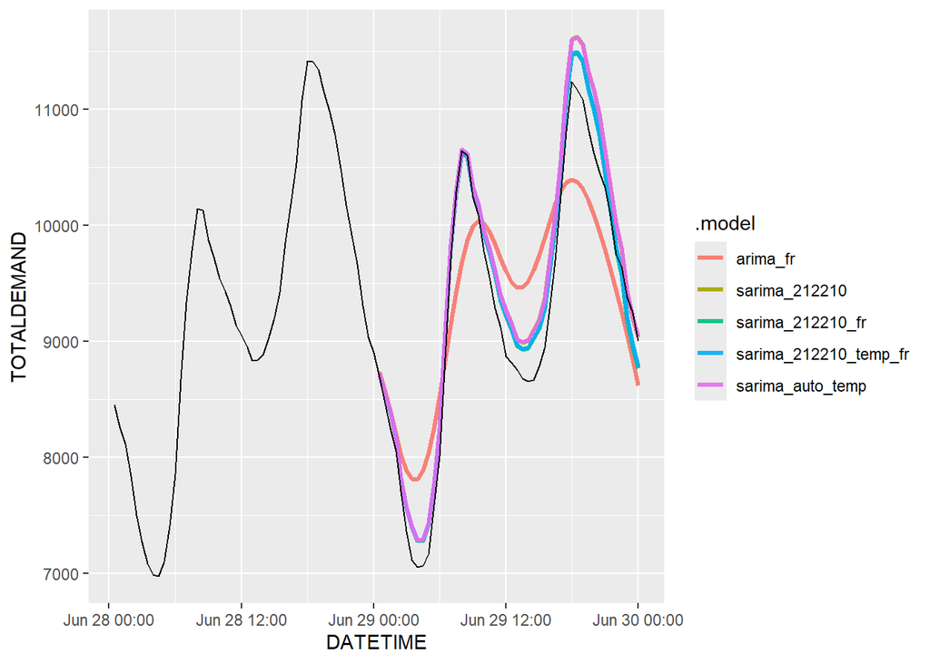

Figure 5.2: Comparison of Model Forecasts.

```r
forecasts %>% autoplot(tail(dfts_nsw, 96), level=NULL, size=1.2, alpha=0.9)
```

## 5.3 Final Model - SARIMA_212210[48] with Weekly Fourier and Temperature

We utilizes the roll forward validation method, to forecast 24 hours ahead 5 consecutive days.

```r
plan(multisession)
```

```r
initial_train_end <- nrow(dfts_nsw) - 48 * 5  # Training data ends 5 days before the dataset's end
forecast_horizon <- 48  # Forecasting one day ahead (48 half-hour intervals)
forecasts_list <- vector("list", 5)  # Store each forecast

future_list <- vector("list", 5)  # List to store futures

for (i in 1:5) {
  future_list[[i]] <- future({
    train_data <- dfts_nsw[1:(initial_train_end + (i - 1) * forecast_horizon), ]

    cat(sprintf("Fit %d starting: %s\n", i, Sys.time()))

    fit_arima <- train_data %>%
      model(sarima_212210_temp_fr = ARIMA(TOTALDEMAND ~ pdq(2, 1, 2) + PDQ(2, 1, 0, period = 48) +
                                          TEMPERATURE + TEMPERATURE_SQ +
                                          fourier(K = 3, period = 48*7)))

    cat(sprintf("Fit %d done: %s\n", i, Sys.time()))

    test_set <- dfts_nsw[(initial_train_end + (i - 1) * forecast_horizon + 1):(initial_train_end + i * forecast_horizon), ]
    forecasts <- forecast(fit_arima, new_data = test_set)
    return(forecasts)
  })
}

# Collecting results from futures
for (i in 1:5) {
  forecasts_list[[i]] <- value(future_list[[i]])
}
```

```
## Fit 1 starting: 2024-04-19 16:25:10
## Fit 1 done: 2024-04-19 16:57:44
## Fit 2 starting: 2024-04-19 16:25:11
## Fit 2 done: 2024-04-19 16:57:45
## Fit 3 starting: 2024-04-19 16:25:11
## Fit 3 done: 2024-04-19 16:57:45
## Fit 4 starting: 2024-04-19 16:25:11
## Fit 4 done: 2024-04-19 16:57:54
## Fit 5 starting: 2024-04-19 16:25:11
## Fit 5 done: 2024-04-19 16:57:50
```

```r
# Combine forecasts into a single tsibble for plotting or evaluation
combined_forecasts <- bind_rows(forecasts_list) %>% as_tibble()
```

```r
# Extract forecast means
forecast_means <- combined_forecasts %>%
  select(.mean) %>%
  pull()

# Create a time series object from the forecasted means
pred_arima_ts <- ts(forecast_means, start = c(ceiling((initial_train_end + 1) / 48), (initial_train_end + 1) %% 48), frequency = 48)

# Actual data corresponding to the forecast periods
actual_indices <- seq(initial_train_end + 1, nrow(dfts_nsw))
actual_data <- dfts_nsw$TOTALDEMAND[actual_indices]

# Calculate accuracy metrics
accuracy_metrics <- accuracy(pred_arima_ts, actual_data)
print(accuracy_metrics)
```

```
##                ME     RMSE      MAE      MPE     MAPE
## Test set 207.8494 466.8003 335.8797 2.117834 3.524567
```

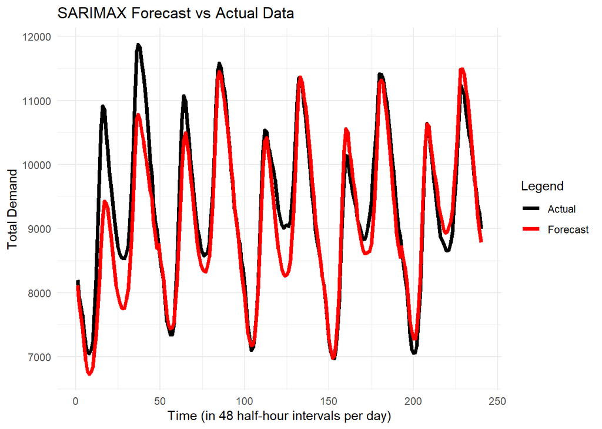

Figure 5.3: Forecast of SARIMA_212210[48] with Weekly Fourier and Temperature.

```r
# Create a data frame for plotting
plot_data <- data.frame(
  Time = seq_along(actual_data),
  Actual = actual_data,
  Forecast = as.numeric(pred_arima_ts)
)

# Creating the plot
p <- ggplot(plot_data, aes(x = Time)) +
  geom_line(aes(y = Actual, colour = "Actual"), size = 1.5) +
  geom_line(aes(y = Forecast, colour = "Forecast"), size = 1.5) +
  scale_color_manual(values = c("Actual" = "black", "Forecast" = "red")) +
  labs(title = "SARIMAX Forecast vs Actual Data",
       x = "Time (in 48 half-hour intervals per day)",
       y = "Total Demand",
       colour = "Legend") +
  theme_minimal()

# Display the plot
print(p)
```

## 5.4 Comparison with Benchmark

```r
benchmark_test <- dfts_nsw[initial_train_end:nrow(dfts_nsw),]

# Calculate accuracy metrics
benchmark_accuracy <- accuracy(benchmark_test$FORECASTDEMAND, benchmark_test$TOTALDEMAND)
print(benchmark_accuracy)
```

```
##                 ME     RMSE      MAE        MPE      MAPE
## Test set -18.28552 96.56456 75.64261 -0.2047934 0.8000381
```

```r
benchmark_test <- benchmark_test %>%
  mutate(Benchmark = FORECASTDEMAND)
```

```r
full_data <- benchmark_test %>%
  left_join(combined_forecasts, by = "DATETIME") %>%
  rename(Forecast = `.mean`)
```

```r
# Merge the data frames by 'Metric'
comparison_table <- rbind(accuracy_metrics, benchmark_accuracy)

row.names(comparison_table) <- rep(c("Our Forecast", "Benchmark"), each = nrow(accuracy_metrics))
# Display the comparison table
print(comparison_table)
```

```
##                     ME      RMSE       MAE        MPE      MAPE
## Our Forecast 207.84938 466.80030 335.87966  2.1178338 3.5245671
## Benchmark    -18.28552  96.56456  75.64261 -0.2047934 0.8000381
```

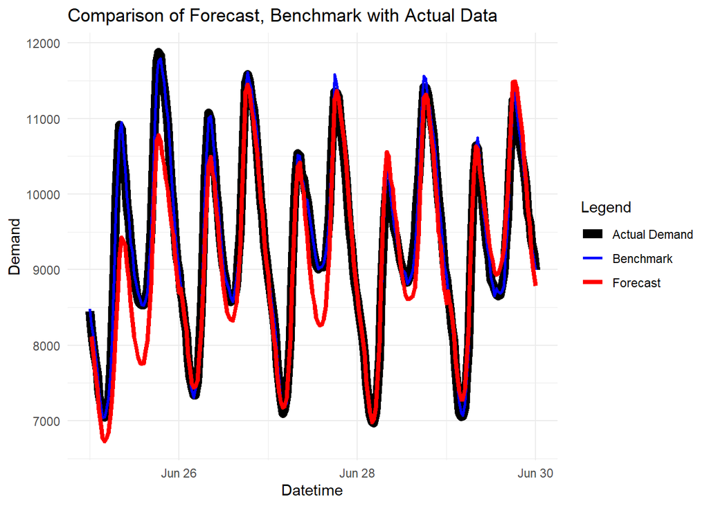

Figure 5.4: Comparison of Benchmark and Our Final Model against the Actual Demand.

```r
# Create the plot
plot <- ggplot(full_data, aes(x = DATETIME)) +
  geom_line(aes(y = TOTALDEMAND.x, color = "Actual Demand"), size = 3) +
  geom_line(aes(y = Benchmark, color = "Benchmark"), size = 1) +
  geom_line(aes(y = Forecast, color = "Forecast"), size = 1.5) +
  scale_color_manual(values = c("Actual Demand" = "black",
                                "Benchmark" = "blue",
                                "Forecast" = "red")) +
  labs(title = "Comparison of Forecast, Benchmark with Actual Data",
       x = "Datetime",
       y = "Demand",
       color = "Legend") +
  theme_minimal()

# Display the plot
print(plot)
```

# 6 Conclusion